# Reproducible Research: Peer Assessment 1

## Loading and preprocessing the data

Unzip the file and load the data.

```r
unzip("activity.zip")
activityData <- read.csv("activity.csv")
```

A look at the data to confirm its dimensions and contents.

```r
head(activityData)
```

```
##   steps       date interval
## 1    NA 2012-10-01        0
## 2    NA 2012-10-01        5
## 3    NA 2012-10-01       10
## 4    NA 2012-10-01       15
## 5    NA 2012-10-01       20
## 6    NA 2012-10-01       25
```

```r
str(activityData)
```

```
## 'data.frame':    17568 obs. of  3 variables:
##  $ steps   : int  NA NA NA NA NA NA NA NA NA NA ...
##  $ date    : chr  "2012-10-01" "2012-10-01" "2012-10-01" "2012-10-01" ...
##  $ interval: int  0 5 10 15 20 25 30 35 40 45 ...
```

## What is mean total number of steps taken per day?

Calculate the total number of steps taken per day and to see the data.

```r
stepsPerDay <- aggregate(steps ~ date, activityData, sum, na.rm=TRUE)
head(stepsPerDay)
```

```
##         date steps
## 1 2012-10-02   126
## 2 2012-10-03 11352
## 3 2012-10-04 12116
## 4 2012-10-05 13294
## 5 2012-10-06 15420
## 6 2012-10-07 11015
```

A histogram of the total number of steps taken each day.

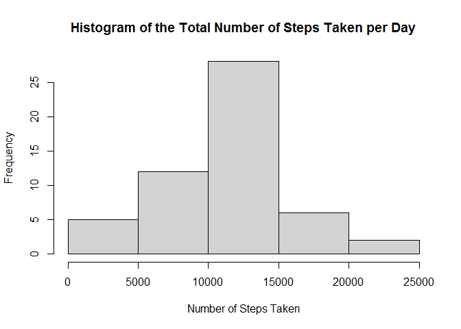

```r
hist(stepsPerDay$steps, xlab="Number of Steps Taken",
     main="Histogram of the Total Number of Steps Taken per Day"
     )
```

Calculate the mean and median values of the total number of steps taken per day.

```r
library(dplyr)
totalStepsSummary <- summarise(stepsPerDay, meanOfTotalSteps=mean(stepsPerDay$steps),
                               medianOfTotalSteps=median(stepsPerDay$steps))
print(totalStepsSummary)
```

```
##   meanOfTotalSteps medianOfTotalSteps
## 1         10766.19              10765
```

## What is the average daily activity pattern?

Average number of steps taken for each interval.

```r
stepsPerInterval <- aggregate(steps ~ interval, activityData, mean, na.rm=TRUE)
head(stepsPerInterval)
```

```
##   interval     steps
## 1        0 1.7169811
## 2        5 0.3396226
## 3       10 0.1320755
## 4       15 0.1509434
## 5       20 0.0754717
## 6       25 2.0943396
```

Create a time series plot, with each interval on the x axis, and the average steps data on the y axis.

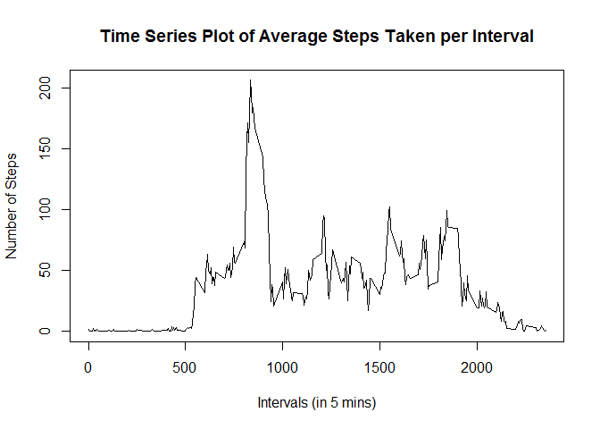

```r
plot(steps~interval, data=stepsPerInterval, type="l",
     main="Time Series Plot of Average Steps Taken per Interval",
     ylab="Number of Steps", xlab="Intervals (in 5 mins)"
     )
```

Which five minute interval contains the maximum number of steps?

```r
intervalWithMaxNbSteps <- stepsPerInterval[which.max(stepsPerInterval$steps),]$interval
intervalWithMaxNbSteps
```

```
## [1] 835
```